# KEGG Pathway-Map Convergence Across the Four Significant LR Lists

Do genes from different cell-type pairs’ significant LR lists belong to the same named KEGG pathway?

Published

October 9, 2026

## 1 Overview

This notebook asks: does a gene from one of the four significant-LR lists belong to a **curated KEGG pathway diagram** – and if so, does a gene from a *different* cell-type-pair’s list also belong to that same diagram?

```r
library(dplyr)
library(tibble)

if (!requireNamespace("KEGGREST", quietly = TRUE)) {
  if (!requireNamespace("BiocManager", quietly = TRUE)) install.packages("BiocManager")
  BiocManager::install("KEGGREST", update = FALSE, ask = FALSE)
}
library(KEGGREST)
```

## 2 Helpers: exact-match KEGG gene resolution + pathway membership, with local caching

`KEGGREST::keggFind()` does a **substring** search across gene names and aliases. Results are cached to a local RDS file

```r
out_dir <- file.path("output", "04_KEGG_PathwayConvergence")
dir.create(out_dir, recursive = TRUE, showWarnings = FALSE)

kegg_cache_path <- file.path(out_dir, "kegg_pathway_cache.rds")
kegg_cache <- if (file.exists(kegg_cache_path)) readRDS(kegg_cache_path) else list()

save_kegg_cache <- function() saveRDS(kegg_cache, kegg_cache_path)

#' Resolve a gene symbol to its exact KEGG gene ID (e.g. "mmu:19242") for a
#' given organism code ("mmu" = mouse, "hsa" = human). Returns NA if no exact
#' match is found among that gene's own alias list.
resolve_kegg_gene_id <- function(gene_symbol, organism = "mmu") {
  hits <- tryCatch(KEGGREST::keggFind(organism, gene_symbol), error = function(e) NULL)
  if (is.null(hits) || length(hits) == 0) return(NA_character_)

  # hits is a named character vector: names = "mmu:19242", values = "Ptn, HARP, ...; pleiotrophin precursor"
  aliases_by_hit <- hits %>%
    stringr::str_split(";") %>%
    purrr::map_chr(1) %>%
    stringr::str_split(",\\s*")

  exact_match <- purrr::map_lgl(aliases_by_hit, ~ gene_symbol %in% .x)
  matched_ids <- names(hits)[exact_match]

  if (length(matched_ids) == 0) return(NA_character_)
  matched_ids[1]  # first exact match if somehow more than one
}

#' Full mouse pathway id -> name lookup table, fetched once and cached
#' (one API call returns all mouse pathways; KEGG's /list endpoint 404s on a
#' single "path:mmuXXXXX" entry, so names are joined locally instead).
get_mmu_pathway_names <- function() {
  cache_key <- "mmu_pathway_names_table"
  if (!is.null(kegg_cache[[cache_key]])) return(kegg_cache[[cache_key]])

  raw <- KEGGREST::keggList("pathway", "mmu")
  tbl <- tibble(pathway_id = names(raw), pathway_name = stringr::str_remove(unname(raw), " - .*$"))

  kegg_cache[[cache_key]] <<- tbl
  save_kegg_cache()
  tbl
}
mmu_pathway_names <- get_mmu_pathway_names()

#' Get the set of KEGG pathway IDs + names a gene belongs to. Cached.
get_kegg_pathways <- function(gene_symbol, organism = "mmu") {
  cache_key <- paste(organism, gene_symbol, sep = "::")
  if (!is.null(kegg_cache[[cache_key]])) return(kegg_cache[[cache_key]])

  kegg_id <- resolve_kegg_gene_id(gene_symbol, organism)
  result <- if (is.na(kegg_id)) {
    tibble(gene = gene_symbol, kegg_id = NA_character_, pathway_id = NA_character_, pathway_name = NA_character_)
  } else {
    links <- tryCatch(KEGGREST::keggLink("pathway", kegg_id), error = function(e) character(0))
    if (length(links) == 0) {
      tibble(gene = gene_symbol, kegg_id = kegg_id, pathway_id = NA_character_, pathway_name = NA_character_)
    } else {
      pathway_ids <- stringr::str_remove(unname(links), "^path:")
      tibble(gene = gene_symbol, kegg_id = kegg_id, pathway_id = pathway_ids) %>%
        dplyr::left_join(mmu_pathway_names, by = "pathway_id")
    }
  }

  kegg_cache[[cache_key]] <<- result
  save_kegg_cache()
  Sys.sleep(0.34)  # free KEGG REST API (~3 req/sec)
  result
}
```

## 3 Load the four significant-LR lists

Reads `significant_lr_pairs.csv`, exported by `03c_crossModality_plots.qmd`: the pairs where spatial slope, spatial detection enrichment, and scRNA `magnitude_rank` all agree in sign on their young-to-old shift (the pairs shown in 03c’s `plot_cross_modality_trajectory()` plots).

```r
# Named only for display / for the pathview color-coding step further down
spatial_pair_labels <- c("Astrocyte-Vascular", "Vascular-Microglia",
                          "OPC-Cajal.Retzius", "Neurogenic_lineage-GC")

sig_pairs <- read.csv(file.path("output", "03c_crossModality_plots", "significant_lr_pairs.csv"), stringsAsFactors = FALSE) %>%
  distinct(spatial_pair, ligand_complex, receptor_complex)

# Complexes come through as e.g. "GeneA_GeneB" -- split those into individual
# subunits before KEGG lookup, since KEGG genes are single proteins.
split_complex <- function(x) stringr::str_split(x, "_")

lr_gene_sets <- purrr::pmap(sig_pairs, function(spatial_pair, ligand_complex, receptor_complex) {
  ligands   <- unlist(split_complex(ligand_complex))
  receptors <- unlist(split_complex(receptor_complex))
  tibble(
    spatial_pair = spatial_pair,
    gene = unique(c(ligands, receptors)),
    role = ifelse(unique(c(ligands, receptors)) %in% ligands, "ligand", "receptor")
    # note: a gene acting as both ligand and receptor across different rows
    # will just get whichever role its first occurrence had -- role is
    # informational only and doesn't affect the pathway lookup below.
  )
})

lr_genes_long <- bind_rows(lr_gene_sets) %>% distinct(spatial_pair, gene, role)
lr_genes_long
```

| spatial_pair | gene | role |
| --- | --- | --- |
| Astrocyte-Vascular | Ptn | ligand |
| Astrocyte-Vascular | Sdc4 | receptor |
| Astrocyte-Vascular | Ptprs | receptor |
| Astrocyte-Vascular | Fgfr3 | ligand |
| Astrocyte-Vascular | Epha4 | receptor |
| Astrocyte-Vascular | Cxcl12 | ligand |
| Astrocyte-Vascular | Itgb1 | receptor |
| Astrocyte-Vascular | Mif | ligand |
| Astrocyte-Vascular | Ackr3 | receptor |
| Astrocyte-Vascular | Vtn | ligand |

[output cut: 59 more lines]

## 4 Cross-reference every gene against KEGG pathway membership

This is the step that hits the KEGG API (cached after the first run, so re-rendering is fast).

```r
unique_genes <- unique(lr_genes_long$gene)

gene_pathway_map <- purrr::map_dfr(unique_genes, get_kegg_pathways) %>%
  filter(!is.na(pathway_id))

# Join back to spatial_pair (a gene can appear in more than one LR list) --
# keep role here (not just spatial_pair/gene) since convergence-detail below
# selects it back out.
gene_pathway_by_pair <- lr_genes_long %>%
  distinct(spatial_pair, gene, role) %>%
  inner_join(gene_pathway_map, by = "gene")

gene_pathway_by_pair
```

| spatial_pair | gene | role | kegg_id | pathway_id | pathway_name |
| --- | --- | --- | --- | --- | --- |
| Astrocyte-Vascular | Sdc4 | receptor | mmu:20971 | mmu04512 | ECM-receptor interaction |
| Astrocyte-Vascular | Sdc4 | receptor | mmu:20971 | mmu04514 | Cell adhesion molecule (CAM) interaction |
| Astrocyte-Vascular | Sdc4 | receptor | mmu:20971 | mmu04820 | Cytoskeleton in muscle cells |
| Astrocyte-Vascular | Sdc4 | receptor | mmu:20971 | mmu05205 | Proteoglycans in cancer |
| Astrocyte-Vascular | Sdc4 | receptor | mmu:20971 | mmu05418 | Fluid shear stress and atherosclerosis |
| Astrocyte-Vascular | Ptprs | receptor | mmu:19280 | mmu04514 | Cell adhesion molecule (CAM) interaction |
| Astrocyte-Vascular | Ptprs | receptor | mmu:19280 | mmu04517 | IgSF CAM signaling |
| Astrocyte-Vascular | Fgfr3 | ligand | mmu:14184 | mmu01521 | EGFR tyrosine kinase inhibitor resistance |
| Astrocyte-Vascular | Fgfr3 | ligand | mmu:14184 | mmu04010 | MAPK signaling pathway |
| Astrocyte-Vascular | Fgfr3 | ligand | mmu:14184 | mmu04014 | Ras signaling pathway |

[output cut: 513 more lines]

## 5 Convergence pathways: hit by 2+ different cell-type-pair analyses

```r
convergence_pathways <- gene_pathway_by_pair %>%
  distinct(spatial_pair, pathway_id, pathway_name, gene) %>%
  group_by(pathway_id, pathway_name) %>%
  summarise(
    n_spatial_pairs_hitting_it = n_distinct(spatial_pair),
    n_distinct_genes           = n_distinct(gene),
    .groups = "drop"
  ) %>%
  filter(n_spatial_pairs_hitting_it >= 2) %>%
  # The interesting case is *different* genes from different lists landing on
  # the same pathway
  arrange(desc(n_distinct_genes > 1), desc(n_spatial_pairs_hitting_it))

convergence_pathways
```

| pathway_id | pathway_name | n_spatial_pairs_hitting_it | n_distinct_genes |
| --- | --- | --- | --- |
| mmu04014 | Ras signaling pathway | 4 | 6 |
| mmu04015 | Rap1 signaling pathway | 4 | 8 |
| mmu04020 | Calcium signaling pathway | 4 | 7 |
| mmu04148 | Efferocytosis | 4 | 6 |
| mmu04360 | Axon guidance | 4 | 7 |
| mmu04820 | Cytoskeleton in muscle cells | 4 | 7 |
| mmu04919 | Thyroid hormone signaling pathway | 4 | 2 |
| mmu05010 | Alzheimer disease | 4 | 7 |
| mmu05022 | Pathways of neurodegeneration | 4 | 4 |
| mmu05163 | Human cytomegalovirus infection | 4 | 6 |

[output cut: 80 more lines]

For each convergence pathway, which genes (and from which spatial pair) actually land there:

```r
convergence_detail <- gene_pathway_by_pair %>%
  semi_join(convergence_pathways, by = "pathway_id") %>%
  arrange(pathway_id, spatial_pair) %>%
  dplyr::select(pathway_id, pathway_name, spatial_pair, gene, role)

convergence_detail
```

| pathway_id | pathway_name | spatial_pair | gene | role |
| --- | --- | --- | --- | --- |
| mmu01521 | EGFR tyrosine kinase inhibitor resistance | Astrocyte-Vascular | Fgfr3 | ligand |
| mmu01521 | EGFR tyrosine kinase inhibitor resistance | Astrocyte-Vascular | Pdgfb | ligand |
| mmu01521 | EGFR tyrosine kinase inhibitor resistance | OPC-Cajal.Retzius | Pdgfa | ligand |
| mmu01521 | EGFR tyrosine kinase inhibitor resistance | OPC-Cajal.Retzius | Pdgfra | receptor |
| mmu01521 | EGFR tyrosine kinase inhibitor resistance | Vascular-Microglia | Pdgfb | ligand |
| mmu03271 | Virion | Astrocyte-Vascular | Itgb1 | receptor |
| mmu03271 | Virion | Vascular-Microglia | Itgb1 | receptor |
| mmu04010 | MAPK signaling pathway | Astrocyte-Vascular | Fgfr3 | ligand |
| mmu04010 | MAPK signaling pathway | Astrocyte-Vascular | Pdgfb | ligand |
| mmu04010 | MAPK signaling pathway | Astrocyte-Vascular | Vegfb | ligand |

[output cut: 446 more lines]

## 6 Export for downstream synthesis

Used in `06_Synthesis_FunctionBySpatialPair.qmd`, which combines this notebook’s KEGG-pathway convergence with `05_STRING_NetworkAnalysis.qmd`’s cluster convergence into one summary.

```r
write.csv(gene_pathway_by_pair, file.path(out_dir, "kegg_gene_pathway_by_pair.csv"), row.names = FALSE)
write.csv(convergence_pathways, file.path(out_dir, "kegg_convergence_pathways.csv"), row.names = FALSE)
```

## 7 Notes on interpretation

A pathway showing up as “convergent” here means genes from two different cell-type-pair analyses both belong to that named KEGG map – it does not mean the two LR pairs interact directly, only that both push their respective cell types toward the same broader curated pathway.

## 8 Render the actual KEGG diagram with your genes highlighted

```r
if (!requireNamespace("pathview", quietly = TRUE)) BiocManager::install("pathview", update = FALSE, ask = FALSE)
if (!requireNamespace("org.Mm.eg.db", quietly = TRUE)) BiocManager::install("org.Mm.eg.db", update = FALSE, ask = FALSE)
library(pathview)
library(org.Mm.eg.db)
```

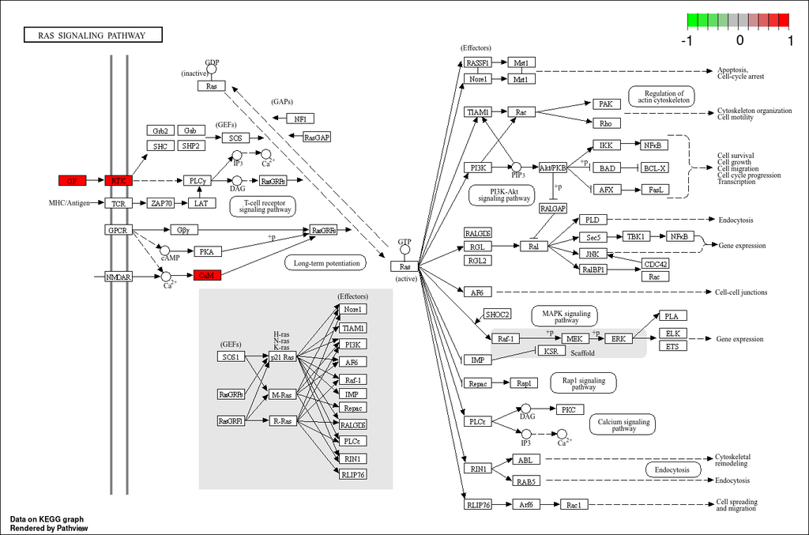

```r
# Example: render the top convergence pathway from the table above.
target_pathway_id <- stringr::str_remove(convergence_pathways$pathway_id[1], "^mmu")

pair_codes <- setNames(seq_along(spatial_pair_labels), spatial_pair_labels)

gene_group_code <- gene_pathway_by_pair %>%
  filter(pathway_id == convergence_pathways$pathway_id[1]) %>%
  distinct(gene, spatial_pair) %>%
  group_by(gene) %>%
  summarise(code = if (n() > 1) length(spatial_pair_labels) + 1 else pair_codes[spatial_pair[1]], .groups = "drop")

gene_data_vec <- setNames(gene_group_code$code, gene_group_code$gene)

map_symbol_to_entrez <- function(gene_symbols, orgdb = org.Mm.eg.db) {
  safe_map <- function(keys_vec, keytype) {
    if (length(keys_vec) == 0) return(character(0))
    tryCatch(
      AnnotationDbi::mapIds(orgdb, keys = keys_vec, column = "ENTREZID", keytype = keytype, multiVals = "first"),
      error = function(e) setNames(rep(NA_character_, length(keys_vec)), keys_vec)
    )
  }

  primary <- safe_map(gene_symbols, "SYMBOL")
  unresolved <- names(primary)[is.na(primary)]
  if (length(unresolved) > 0) {
    fallback <- safe_map(unresolved, "ALIAS")
    still_na <- is.na(fallback)
    primary[names(fallback)[!still_na]] <- fallback[!still_na]
  }
  primary
}

entrez_ids <- map_symbol_to_entrez(names(gene_data_vec))

gene_data_entrez <- gene_data_vec
names(gene_data_entrez) <- unname(entrez_ids[names(gene_data_vec)])
unmapped <- gene_group_code$gene[is.na(names(gene_data_entrez))]
if (length(unmapped) > 0) {
  message("Dropping gene(s) with no org.Mm.eg.db Entrez match (via SYMBOL or ALIAS): ", paste(unmapped, collapse = ", "))
}
gene_data_entrez <- gene_data_entrez[!is.na(names(gene_data_entrez))]

if (length(gene_data_entrez) == 0) {
  stop("None of this pathway's genes resolved to an Entrez ID via org.Mm.eg.db -- ",
       "check gene symbol spelling/casing in the significant-LR CSVs.")
}

old_wd <- setwd(out_dir)
tryCatch(
  pathview(
    gene.data   = gene_data_entrez,
    pathway.id  = target_pathway_id,
    species     = "mmu",
    gene.idtype = "entrez",
    out.suffix  = "convergence",
    kegg.native = TRUE
  ),
  finally = setwd(old_wd)
)
# Produces mmu<target_pathway_id>.convergence.png in out_dir --
# the official KEGG diagram with your genes colored by contributing list.
knitr::include_graphics(file.path(out_dir, paste0("mmu", target_pathway_id, ".convergence.png")))
```